# beatochess no. 10 (May 2025)

Beat Neuenschwander, neuenschwander.beat@gmail.com, https://github.com/beatochess/

# Comments and revisions

## Prize winners

Date: May 5, 2025

File: Kasparyan1982a.pgn

In the second mainline **3… Kg2**, which is obviously stronger than **3… Ke4** (mate in 1), **6. Ba5!** is a cook.

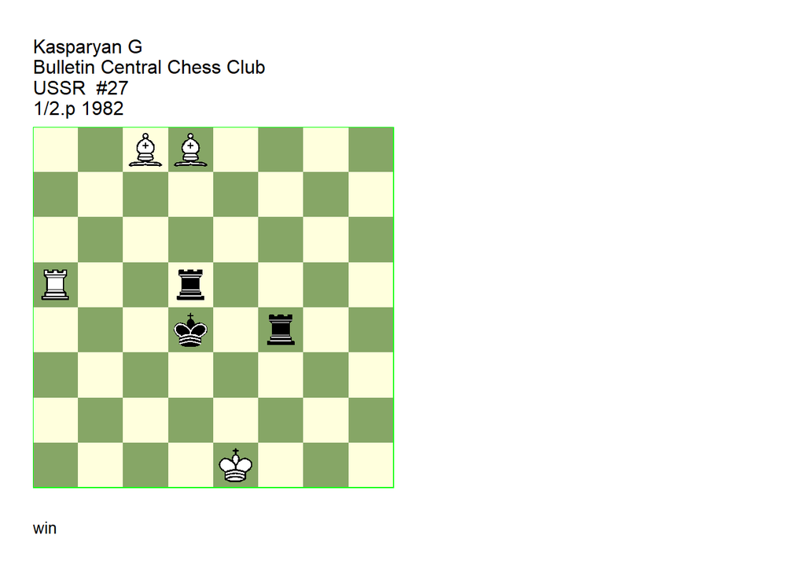

GBR: +0720.00e1d4 U2 FEN: 2BB4/8/8/R2r4/3k1r2/8/8/4K3 w - - 0 1

Bulletin Central Chess Club USSR=30 Bulletin Central Chess Club USSR/12 1983 (EG#06746).U2: Neuenschwander=B beatochess 05/05/2025. **1. Bb6+! Ke4 2. Ra4+** (2. Bb7? Rf5) **2… Kf3 3. Ra3+ Ke4** (3… Kg2 **main** 4. Bb7 Rf1+ (4… Re4+ 5. Re3 Rxe3+ 6. Bxe3 Kf3 7. Bc1 Ke4 8. Bb2) 5. Ke2 Rd1 6. Be3! (6. Ra5? Rd2+ 7. Ke3 Rd3+) (6. Ba5! **cook** **BN** 6… Rd4 (6… Kh2 7. Bxd5 Rxd5 8. Bc7+) 7. Re3! Kg1 8. Bxd5) 6… Kh3 (6… Kh2 7. Bf4+) 7. Bd2+) **4. Re3# 1-0**.

### Banaszek +0810.00g8e8 (1985). Correction

Date: May 5, 2025

File: Banaszek1985a.pgn

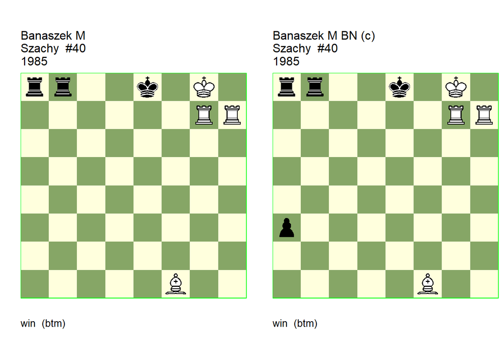

GBR: +0810.00g8e8 U2 FEN: rr2k1K1/6RR/8/8/8/8/8/5B2 b q - 0 1

Szachy=8(461) Szachy/8 (EG#06774). U2: Garcia=M HHdbV#29177 22-9-2011. **1… Rb7! 2. Bb5+!** (2. Rh8? O-O-O+!) (2. Rxb7? O-O-O+!) **2… Rxb5 3. Re7+!** (3. Rh8? O-O-O+) **3… Kd8 4. Kf7 Rf5+ 5. Ke6 Rf8 6. Rd7+ Kc8 7. Rc7+ Kb8 8. Rb7+ Kc8 9. Rhc7+ Kd8 10. Rd7+ Ke8** (10… Kc8 11. Ke7) **11. Ra7! Rb8 12. Rdb7!** (12. Kd6! **cook** MG 12… Rf1 13. Kc7 Rfb1 14. Rh7 Rd8 15. Rh8+ Ke7 16. Rxd8) **12… Rc8 13. Re7+ Kd8 14. Rad7# 1-0**.

GBR: +0810.00g8e8 (c) FEN: rr2k1K1/6RR/8/8/8/p7/8/5B2 b q - 0 1

correction: Neuenschwander=B beatochess 05/05/2025. **1… Rb7! 2. Bb5+!** ( 2. Rh8? O-O-O+!) (2. Rxb7? O-O-O+!) **2… Rxb5 3. Re7+!** (3. Rh8? O-O-O+) **3… Kd8 4. Kf7 Rf5+ 5. Ke6 Rf8 6. Rd7+ Kc8 7. Rc7+ Kb8 8. Rb7+ Kc8 9. Rhc7+ Kd8 10. Rd7+ Ke8** (10… Kc8 11. Ke7) **11. Ra7! Rb8 12. Rdb7! Rc8 13. Re7+ Kd8 14. Rad7# 1-0**.

### Belyavsky & Mitrofanov =0410.04g5b8 (1984). Cook

Date: May 5, 2025

File: Belyavsky1984a.pgn

In the orignal study, White seems to hold the balance with **2. Bg6!**. The modification by Polasek is correct.

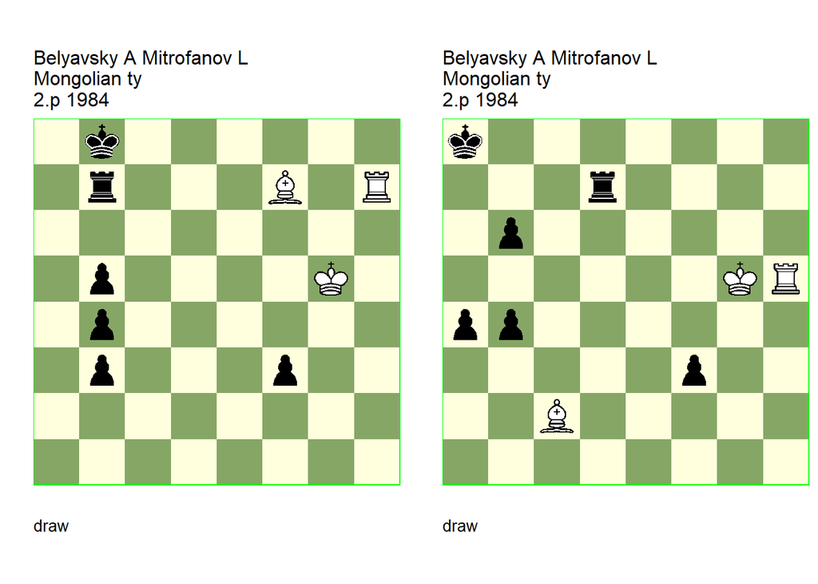

GBR: =0410.04g5b8 U2 FEN: 1k6/1r3B1R/8/1p4K1/1p6/1p3p2/8/8 w - - 0 1

also 8.p Chavchavadze MT 1987 (EG#06798 EG#07742). U2: Neuenschwander=B beatochess 05/05/2025. **1. Rh8+ Ka7 2. Bxb3** (2. Bg6! **cook** **BN** 2… Re7 3. Rf8 Re3 4. Kg4) **2… Rg7+ 3. Kh5 Rf7 4. Bxf7 f2 5. Rh7 Kb8 6. Rh8+ Kc7 7. Rh7 Kd8 8. Rh8+ Ke7 9. Re8+ Kd7 10. Rf8 Ke7 11. Re8+ Kxf7 12. Re4 f1=R** (12… f1=Q 13. Rf4+ Qxf4) **13. Rxb4 Rf5+ 14. Kg4 Ke6 15. Re4+ Re5 16. Kf4 1/2-1/2**.

GBR: =0410.04g5a8 (m) FEN: k7/3r4/1p6/6KR/pp6/5p2/2B5/8 w - - 0 1

modification: Polasek=J EG=219 1/2020. **1. Rh8+** (1. Bxa4? Rd5+) **1… Ka7!** (1… Kb7 2. Bxa4 b5 3. Bb3 Rg7+ 4. Kh5 Rf7 5. Bxf7 f2 6. Bd5+) **2. Bxa4 b5! 3. Bb3!** (3. Bxb5? Rd5+) (3. Bc2? Rd2! 4. Be4 (4. Bf5 Rg2+ 5. Kf4 f2 6. Bd3 Rg1 7. Ke4 f1=Q 8. Bxf1 Rxf1 9. Kd3 Rc1) 4… f2 5. Rh1 Re2 6. Bg2 (6. Bd3 Re3!) 6… b3 7. Rb1 Re1 8. Rxb3 Rg1) **3… Rg7+ 4. Kh5!** (4. Kf4? f2 5. Rh1 Rg1) **4… Rf7! 5. Bxf7 f2 6. Rh7 Kb8 7. Rh8+ Kc7 8. Rh7 Kd8 9. Rh8+ Ke7 10. Re8+!** (10. Rh7? Kf8 11. Rh8+ Kxf7) **10… Kd7 11. Rf8 Ke7 12. Re8+ Kxf7 13. Re4! f1=Q 14. Rf4+ Qxf4 1/2-1/2**.

### Kolesnikov =0300.64h4g2 (1985). Correction

Date: May 5, 2025

File: Kolesnikov1985a.pgn

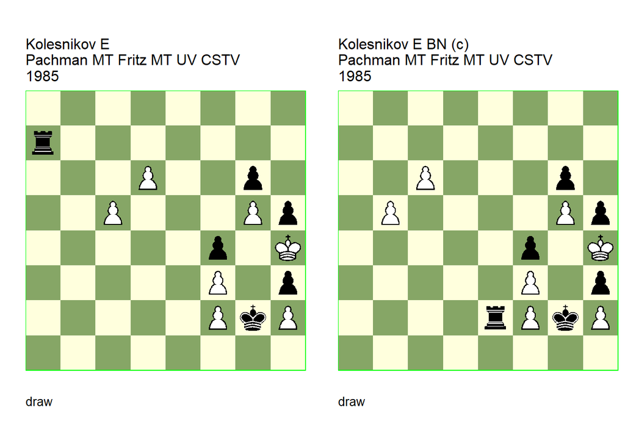

GBR: =0300.64h4g2 U3 FEN: 8/r7/3P2p1/2P3Pp/5p1K/5P1p/5PkP/8 w - - 0 1

(EG#06808). U3: Ceskoslovensky Sach/9 1987 U3: Garcia=M HHdbIV#53769 19-1-2007. **1. c6** (1. d7? Rxd7 2. c6 Kxh2 3. cxd7 Kg2 4. d8=Q h2) **1… Kxh2** ( 1… Ra8! **cook** MG 2. c7 (2. d7 Kxh2 3. d8=Q Rxd8 4. c7 Kg1 5. cxd8=Q h2 6. Qd1+ Kg2 7. Qe1 h1=Q+ 8. Qxh1+ Kxh1 9. Kh3 Kg1 10. Kh4 Kxf2) 2… Kxh2 3. c8=Q Rxc8 4. d7 Rf8 5. d8=Q Kg2 6. Qxf8 h2) **2. c7 Ra8** (2… Kg2 3. c8=Q h2 4. Qh3+ Kg1 5. d7 Rxd7 6. Qxh2+ Kxh2) **3. c8=Q! Rxc8 4. d7 Kg1!** (4… Rc5! **cook** 5. d8=Q Kg2 6. Qd7 Rf5) (4… Kg2 5. dxc8=Q (5. dxc8=B? h2 6. Bh3+ Kg1!) 5… h2 6. Qh3+ Kg1 7. Qxh2+ Kxh2) **5. dxc8=B! 1/2-1/2**.

GBR: =0300.64h4g2 (c) FEN: 8/8/2P3p1/1P4Pp/5p1K/5P1p/4rPkP/8 w - - 0 1

correction: Neuenschwander=B beatochess 05/05/2025. **1. c7 Rc2** (1… Re8 2. b6 Kxh2 3. b7 Kg2 4. c8=Q Rxc8 5. bxc8=Q h2 6. Qh3+ Kg1 7. Qxh2+ Kxh2) **2. b6 Kxh2 3. b7** (3. c8=Q? Rxc8 4. b7 Rf8 5. b8=Q Rf5) **3… Kg1** (3… Rxc7 4. b8=Q Kg2 5. Qc8! h2 6. Qh3+ Kg1 7. Qxh2+ Kxh2) **4. c8=Q** (4. Kxh3? Rxf2) **4… Rxc8 5. bxc8=B** (5. bxc8=Q? h2) **5… h2 6. Bh3! Kxf2** (6… h1=Q) **7. Bg2 Kg1 8. Bh3 h1=B! 9. Bg2! Kh2** (9… Bxg2) (9… Kxg2) **10. Bh3** (10. Bf1 or ) **10… Bxf3 11. Bg2 Bd1** (11… Be2 12. Bf3 Bf1 13. Be4 (13. Bg2? Kg1) 13… Kg1 14. Bxg6 f3 15. Bf7 f2 16. g6 Bd3 17. g7) **12. Bf3 Bc2** (12… Bxf3) **13. Be4 Bd1 14. Bf3** (14. Bxg6? f3 15. Be4 f2 16. Bd3 Bc2 17. Bc4 Bg6) **1/2-1/2**.

### Dolgov & Maksimovskikh +0440.12a7a1 (1986). Cooks

Date: May 6, 2025

File: Dolgov1986a.pgn

In this first-prize winner, both **3. Be6!** and **7. Bc4!** seem winning.

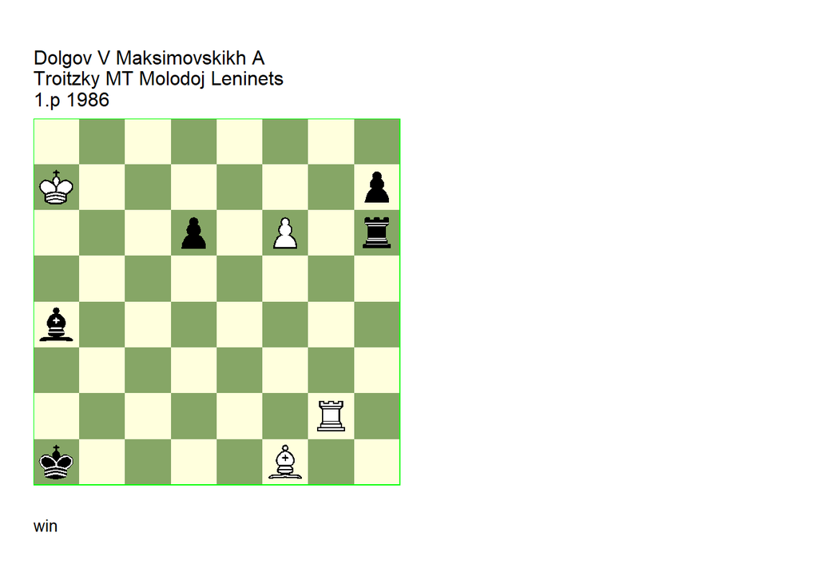

GBR: +0440.12a7a1 U2 FEN: 8/K6p/3p1P1r/8/b7/8/6R1/k4B2 w - - 0 1

(EG#06858). U2: Neuenschwander=B beatochess 06/05/2025. **1. f7 Rf6 2. Bc4 Bb5! 3. Bb3** (3. Rg1+? Kb2 4. Rf1 Rxf7+) (3. Be6! **cook** **BN** 3… Bd7 4. Ra2+ Kb1 5. Bb3) **3… Bd3** (3… d5 4. Bxd5 Bc6 5. Ra2+ Kb1 6. Ra6) **4. Rg8! Bc2 5. Be6 Bf5 6. Rg1+ Bb1** (6… Kb2 7. Rf1) **7. Kb6!** (7. Kb7? Kb2 8. Rg8 Bf5 9. Rg2+ Kc3 10. Rf2? Be4+) (7. Kb8? Kb2 8. Rg8 Bf5 9. Rg2+ Kc3 10. Rf2 Bxe6 11. Rxf6 Bxf7 12. Rxf7 d5) (7. Bc4! **cook** **BN** 7… d5 (7… Kb2 8. Rf1 Bf5 9. Be6) 8. Bxd5 Kb2 9. Rg8 Be4 10. Be6 Bf5 11. Rb8+ Kc3 12. Ba2) **7… Kb2 8. Rg8 Bf5 9. Rg2+ Bc2 10. Kc7 Kc3 11. Rg8 Bf5 12. Rg3+ Bd3 13. Kxd6 1-0**.

### Pervakov =0040.12e3a7 (1986). Changed solution

Date: May 12, 2025

File: Pervakov1986a.pgn

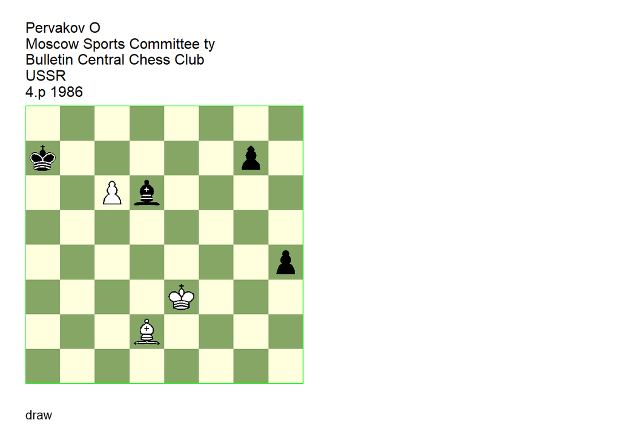

GBR: =0040.12e3a7 U2 (s) FEN: 8/k5p1/2Pb4/8/7p/4K3/3B4/8 w - - 0 1

Bulletin Central Chess Club USSR=18(388) Bulletin Central Chess Club USSR/6 1987 (EG#06906). U2: Garcia=M HHdbV#27426 23-9-2011 U2: Van, der, Heijden=H HHdbV#27426 27-7-2013. Comment: Neuenschwander=B beatochess 12/05/2025.. **1. Kf2!** (1. Kf3? h3 2. Bh6 gxh6! 3. Kf2 Bh2! 4. Kf3 h5!) **1… h3! 2. Bh6! g6** (2… gxh6 3. Kg1) **3. Be3+!** (3. Kf3? Kb6! 4. Be3+ Kxc6 5. Bg1 Kd5 6. Kg4 Ke4! 7. Kxh3 Kf3 8. Kh4 (8. Bd4 g5 9. Bf6 g4+ 10. Kh4 g3 11. Bd4 g2 12. Kh3 (12. Bg1 Bf4 13. Kh5 Bg3 14. Kg5 Ke2 15. Kg4 Kf1) 12… Bg3 13. Bg1 Bf2 14. Bh2 Be1 15. Bg1 Bg3) 8… Bf4) **3… Ka6** (3… Kb8! **main** ! 4. Kf3 Kc7 5. Bg1 Kxc6 6. Kg4 Bc5 7. Bh2) **4. Kf3** (4. c7! **cook** HH 4… Bxc7 5. Kf3! Kb5 6. Bg1 Kc4 7. Kg4 h2 8. Bxh2 Bxh2 9. Kg5) **4… Kb5 5. Bg1!** (5. c7! **cook** MG 5… h2 (5… Bxc7 6. Bg1 Kc4 7. Kg4 h2 8. Bxh2 Bxh2 9. Kg5) 6. c8=Q h1=Q+ 7. Kf2) (5. Bf4? Kxc6 6. Bxd6 Kxd6 7. Kg3 Ke5 8. Kxh3 Kf4) **5… Kxc6** (5… h2 6. Bxh2 Bxh2 7. Kg4) **6. Kg4 Bc5!** (6… Be5 7. Kxh3) **7. Bh2!** ( 7. Kxh3? Bxg1 8. Kg4 Be3) **1/2-1/2**.

### Dobrescu +0800.12h1e3 (1986). Correction

Date: May 17, 2025

File: Dobrescu1986a.pgn

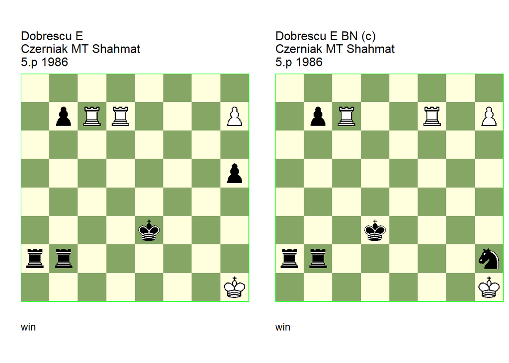

GBR: +0800.12h1e3 U2 FEN: 8/1pRR3P/8/7p/8/4k3/rr6/7K w - - 0 1

(EG#06972). U2: Garcia=M HHdbV#27436 22-9-2011. **1. Rc3+ Ke4 2. Rd4+ Kf5 3. Rc5+ Ke6 4. Re5+ Kf7 5. Rd7+ Kg6 6. Re6+** (6. Rg5+! **cook** MG 6… Kxg5 7. Rg7+ Kf4 8. h8=Q) **6… Kf5 7. Rf6+ Ke4 8. Re7+ Kd5 9. Re5+ Kc4 10. Rf4+ Kd3 11. Rd4+ Kc3 12. h8=Q Rb1+ 13. Rd1 Rxd1+ 14. Re1+ 1-0**.

GBR: +0803.11h1d3 (c) FEN: 8/1pR2R1P/8/8/8/3k4/rr5n/7K w - - 0 1

correction: Neuenschwander=B beatochess 17/052025. **1. Rfd7+** (1. Rc3+? Ke4!) **1… Ke3** (1… Ke4 2. Rd4+!) **2. Rc3+ Ke4 3. Rd4+ Kf5 4. Rc5+ Ke6 5. Re5+ Kf7 6. Rd7+ Kg6 7. Re6+ Kf5 8. Rf6+ Ke4** (8… Ke5 9. h8=Q Rb1+ 10. Rf1+) **9. Re7+ Kd5 10. Re5+ Kc4 11. Rf4+ Kd3 12. Rd4+ Kc3 13. h8=Q Rb1+ 14. Rd1 Rxd1+ 15. Re1+ Kd2 16. Qxh2+ Kxe1 17. Qxa2 1-0**.

### Shmulenson =0313.44d7g7 (1962). Cook

Date: May 18, 2025

File: Shmulenson1962a.pgn

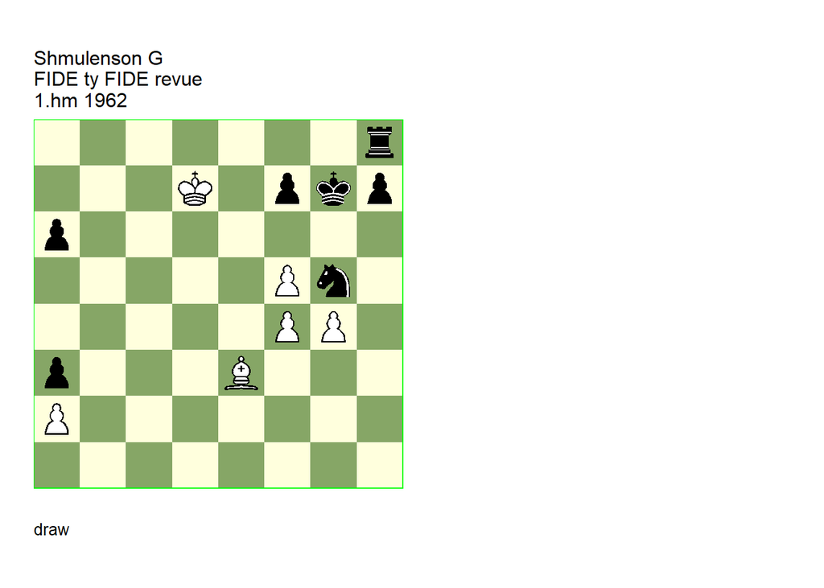

GBR: =0313.44d7g7 U3 FEN: 7r/3K1pkp/p7/5Pn1/5PP1/p3B3/P7/8 w - - 0 1

FIDE revue=3 FIDE revue/7-9 8.p Belarussia champ 1962-1971 (EG#07010). U3: Neuenschwander=B beatochess 18/05/2025. **1. f6+!** (1. Bd4+? f6 2. fxg5 Kf7 3. Bxf6 Rb8) **1… Kh6!** (1… Kg8 2. fxg5 h5 3. g6! fxg6 4. Ke8 Rh7 5. g5! h4 6. Bf4) **2. f5!** (2. fxg5+? Kg6) **2… Rb8 3. Bc5 Nf3 4. Be3+ Ng5 5. Bc5 a5 6. Bd6!** (6. Bxa3? Rb4!) **6… Rg8!** (6… Rb7+! **cook** **BN** 7. Kc6 Nh3 8. Kxb7 Kg5) **7. Bf4!** (7. Bxa3? Nf3 8. Bc1+ Rg5!) **7… Ra8 8. Be3!** (8. Bc1? Rb8) **8… Rb8** (8… Ra6 9. Bc5) **9. Bc5! a4 10. Bxa3!** (10. Bd6? Rg8 11. Bf4 Ra8 12. Bc1 Ra7+! 13. Kc8 (13. Kd8 Ra6 14. Bxa3 Ne6+) (13. Ke8 Rc7 14. Bxa3 Ne4) 13… Ra5 14. Bxa3 Rxf5! 15. gxf5 Ne4 16. Bc1+ Kh5 17. Kd7 Kg4 18. Ke7 h5 19. Kxf7 h4) **10… Ra8 11. Kc7!** (11. Bc5? Rg8 12. Be3 a3! 13. Bc1 Ra8) **11… Ne6+! 12. fxe6 fxe6 13. Kb7!** (13. f7? Ra7+) **13… Rd8** ( 13… Rg8 14. f7 Rg7 15. Bf8) **14. Kc7 Ra8 15. Kb7 1/2-1/2**.

### Afanasiev & Dvizov =0047.01f4a8 (1972). Changed solution

Date: May 18, 2025

File: Afanasiev1972a.pgn

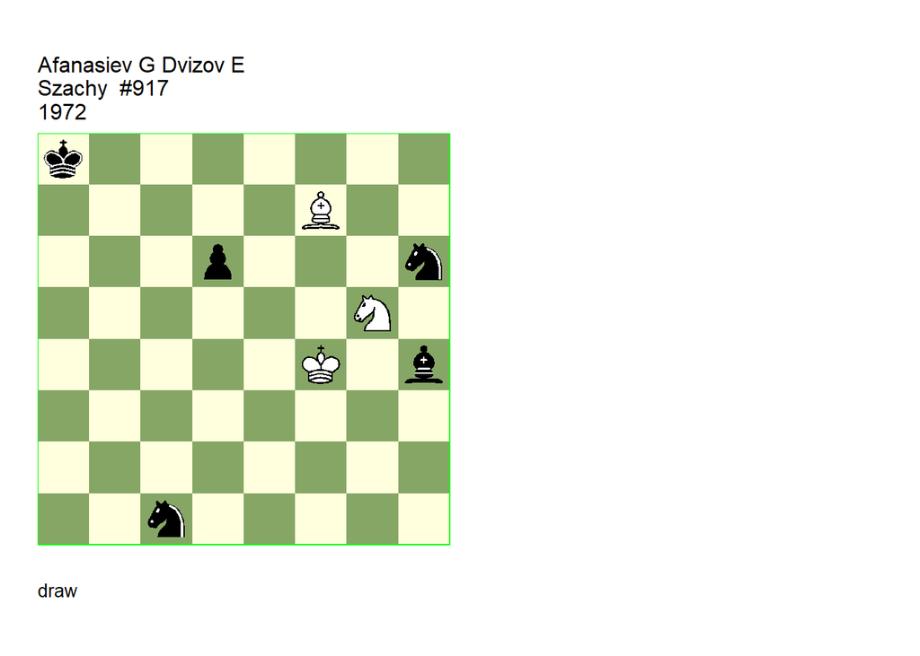

GBR: =0047.01f4a8 U3 FEN: k7/5B2/3p3n/6N1/5K1b/8/8/2n5 w - - 0 1

7/9.p Belarussia champ 1972-1976 (EG#07019). U3: Garcia=M HHdbV#43335 22-9-2011. **1. Bd5+! Kb8! 2. Ne4 Kc7** (2… Nd3+! **cook** MG 3. Ke3 Nb4 4. Be6 d5 5. Nc3 Bg5+ 6. Kf3 d4 7. Ne4 Be3) **3. Ke3! Be1** (3… Nf5+ 4. Kd2 Ne7 5. Bc4 d5 6. Bxd5 Nxd5 7. Kxc1) **4. Kf4! Bh4 5. Ke3! Be1 6. Kf4 1/2-1/2**.

### Belchikov +0030.55f3h4 (1987). Cook

Date: May 19, 2025

File: Belchikov1987a.pgn

**6. Kd4!** cooks the study.

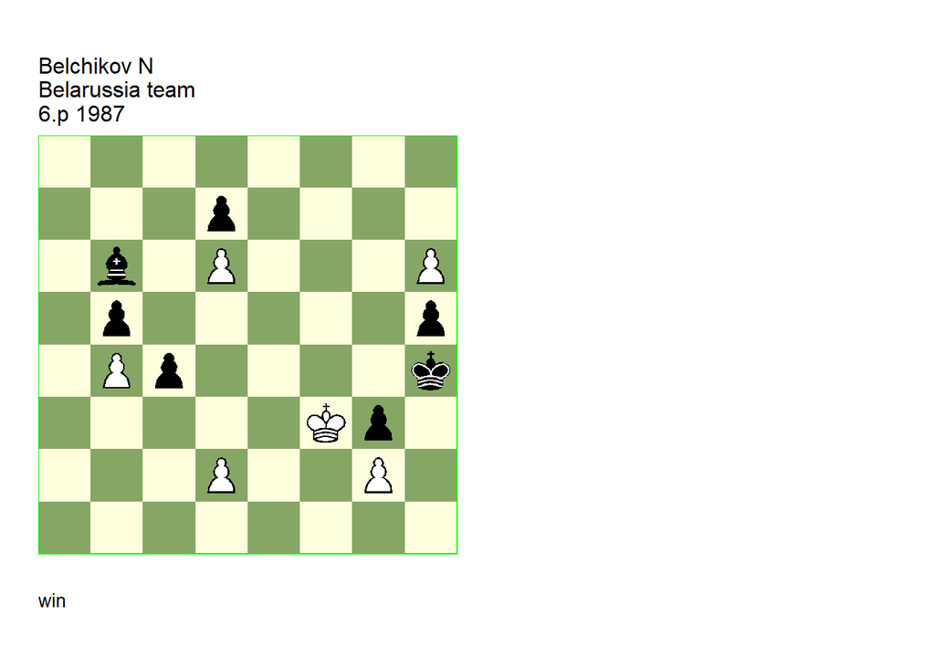

GBR: +0030.55f3h4 TT U2 FEN: 8/3p4/1b1P3P/1p5p/1Pp4k/5Kp1/3P2P1/8 w - - 0 1

(EG#07043). U2: Neuenschwander=B beatochess 19/05/2025. **1. Ke4 Bd8 2. Kf5** (2. Ke5? Bg5 3. h7 Bxd2 4. Kd4 Bc1 5. Kc3 Bh6 6. h8=Q Bg7+ 7. Qxg7) **2… Bb6 3. Ke5 c3 4. dxc3** (4. h7? cxd2 5. h8=Q Bd4+ 6. Kxd4 d1=Q+) **4… Be3 5. h7 Bd2 6. c4** (6. Kd4! **cook** **BN** 6… Bh6 7. c4 Bg7+ 8. Ke4) **6… bxc4** (6… Kg4 7. Kd4 Bc1 8. Kc3) **7. Kf5 Bc3 8. b5 1-0**.

### Krikheli +0100.02c8b4 (1986). Comment

Date: May 21, 2025

File: Krikheli1986a.pgn

This is Tidskrift för Schack 1984, 2nd prize (EG no. 7078).

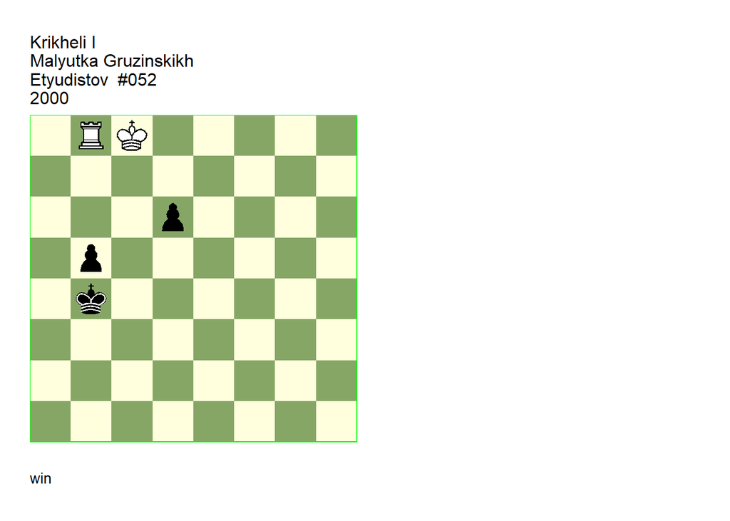

GBR: +0100.02c8b4 PH FEN: 1RK5/8/3p4/1p6/1k6/8/8/8 w - - 0 1

**1. Kc7!** (1. Kd7? Kc4! 2. Rc8+ Kd3 3. Kc6 b4 4. Rb8 Kc4 5. Kb6 d5 6. Ka5 d4 7. Ka4 Kc3 8. Rc8+ Kb2 9. Rd8 Kc3) **1… Kc5! 2. Kb7 d5 3. Rc8+ Kb4 4. Kc6 Kc4 5. Kd6+ Kd4 6. Rb8 Kc4 7. Ke5 b4 8. Kf4 b3** eg **9. Ke3 Kc3 10. Rc8+ Kb2 11. Kd3 Kb1 12. Kc3 b2 13. Rb8 d4+ 14. Kb3 1-0**.

### Waenink +0444.54a6a8 (1985). Cook, correction (Polasek)

Date: May 22, 2025

File: Waenink1985a.pgn

White cannot win at the end, but things are tricky.

The winning position has the white bishops on d8 and e7 and the black bishop on c7, and importantly, Black to move! The position can be reached in Waenink’s study, but only with White to move, which draws as follows: Bf6 Be5! Bde7 Bf4 Bf8 Bc7! B6e7 Kb8! etc.

Jaroslav Polasek came up with a nice correction, in which the critical position is reached with Black to move.

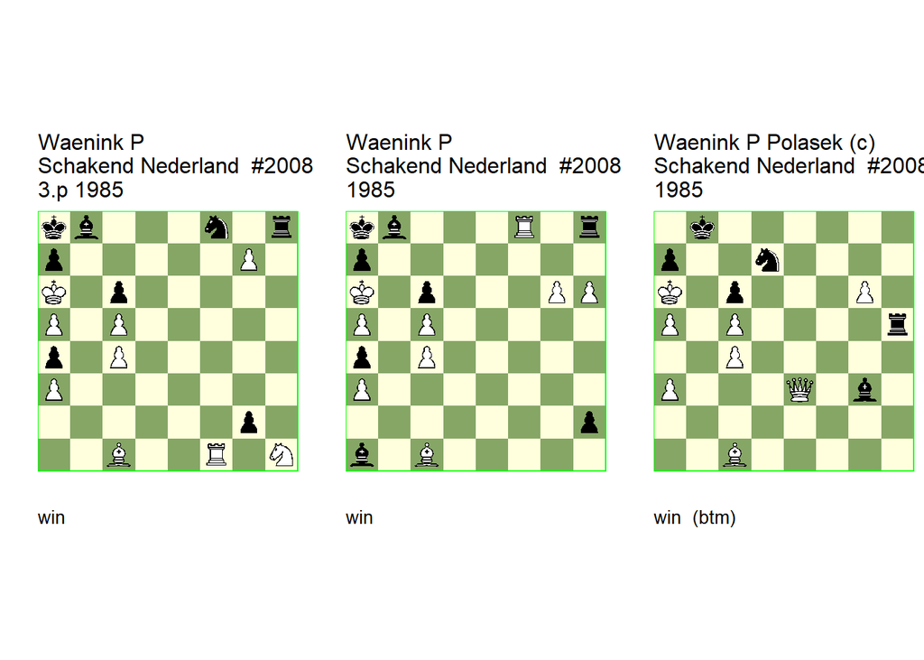

GBR: +0444.54a6a8 (c) FEN: kb3n1r/p5P1/K1p5/P1P5/p1P5/P7/6p1/2B2R1N w - - 0 1

Schakend Nederland/6 (EG#07046). correction: Waenink=P Schakend Nederland/9 1985. **1. Rxf8** (1. gxh8=Q? gxf1=Q) (1. gxf8=Q? Rxf8 2. Rxf8 gxh1=Q 3. Bf4 Qb1) **1… gxh1=Q 2. Rxh8** (2. gxh8=Q? Qxh8 3. Rxh8) **2… Qxh8 3. gxh8=B!** (3. gxh8=Q?) (3. gxh8=N? Bf4! 4. Bb2 Be5 5. Bxe5) **3… Be5 4. Bb2 Bf4 5. Bbf6 Be5 6. Bhg7 Bf4 7. Bd8 Bc7 8. Bgf6 Be5 9. Bh4! Bg3 10. Bde7 Be5 11. Bf8! Bb2 12. Bg5!** (12. Bd8? Bxa3 13. Bg7 Bc1 14. Bb6 a3 15. Bxa7 Bb2) **12… Bxa3** (12… Be5 13. Bd8 Bb2 14. Bb6 Bxa3 15. Bg7 Bc1 16. Bxa7 a3 17. Be5! Bb2 18. Bab8) **13. Bg7! Bb4** (13… Bxc5 14. B5f6 Bd6 15. Bd4 c5 16. Bb2 Be7 17. Ba3 Kb8 18. Kb5 Kc7 19. a6) **14. B5f6 Be1** (14… a3 15. Bc3 Bxc3 16. Bxc3) **15. Bb2 Bg3 16. Ba3 Bc7 17. Bf8 Bd8 18. Bd6 Bc7 19. Be7 Bb8 20. Bc1 Bc7 21. Bb2 a3** (21… Bf4 22. Bd8 Bg3 23. Bb6 Bb8 24. Bc1) **22. Bxa3 1-0**.

GBR: +0470.64a6a8 U3 FEN: kb3R1r/p7/K1p3PP/P1P5/p1P5/P7/7p/b1B5 w - - 0 1

Schakend Nederland/6. U3: Waenink=P Schakend Nederland/9 1985. **1. g7 h1=Q 2. Rxh8 Bxg7** (2… Qh2! **cook** 3. g8=Q Bxh8 4. Qc8 Qc7) **3. hxg7 Qxh8 4. gxh8=B!** (4. gxh8=Q?) **4… Be5 5. Bb2 Bf4 6. Bbf6 Be5 7. Bhg7 Bf4 8. Bd8 Bc7 9. Bgf6 Be5 10. Bh4 Bg3 11. Bde7 Be5 12. Bf8 Bb2 13. Bg5 Bxa3 14. Bg7 Bb4 15. B5f6 Be1 16. Bb2 Bg3 17. Ba3 Bc7 18. Bf8 Bd8 19. Bd6 Bc7 20. Be7 Bb8 21. Bc1 Bc7 22. Bb2 a3 23. Bxa3 1-0**.

correction: Polasek=J Ceskoslevensky Sach 9/2022. **1… Ka8!** (1… Nxc5+ 2. Qxc5 Rxc5 3. g7) **2. Qe8+ Nb8+ 3. Qxb8+ Bxb8! 4. g7 Rh8! 5. gxh8=B!** (5. gxh8=Q) (5. gxh8=N? Bf4! 6. Bb2 (6. Nf7 Bxc1 7. a4 (7. Ne5 Bxa3 8. Nxc6 Bxc5!1) 7… Be3! (7… Kb8 8. Ne5 Be3 ) 8. Ne5 Kb8 (8… Bxc5? 9. Nxc6 Be3 10. Kb5 Kb7 11. a6+ Kc7 (11… Ka8 12. Ne7 Kb8 13. Kc6 Bg5 14. Nf5 Bf4 15. Kd7 Bh2 16. Ne7 Bg3 17. Nc6+ Ka8 18. Kc8 Bf2 19. Nd8 Bg1 20. Ne6 Bh2 21. c5 Bg3 22. c6 Bh2 23. c7) 12. c5) 9. Nxc6+ Kc7 10. Ne5 (10. Kb5 a6+) 10… Bxc5!1 11. Kb5 Bd4 12. Nd3 Be3 13. c5 Bg5 14. Nb4 Bd2 15. Nd5+ Kb7 16. a6+ Kb8 17. Kc6 Be1 18. Kd7 Bf2 19. c6 Bg3 20. c7+ Bxc7 21. Nxc7) 6… Be5 7. Nf7 Bxb2 8. Nd8 (8. a4 Bf6) 8… Bxa3 9. Nxc6 Bxc5!1) **5… Be5 6. Bb2 Bg3 7. Bbf6 Bc7** ( 7… Be5 8. Bhg7 Bc7 9. Be7) **8. Be7 Be5** (8… Kb8 9. Bhf6 Ka8 10. Bd8 Be5 11. Bfe7 Bc7 12. a4) **9. Bhf6 Bc7 10. Bd8 Be5 11. Bfe7 Bc7 12. a4 Bxd8 13. Bxd8 Kb8 14. Bc7+ Ka8 15. Bb6 1-0**.

### Shansin +3126.12g1e1 (1987). Comment, correction

Date: May 23, 2025

File: Shansin1987a.pgn

**2… Kc2** is unclear, although a GBR 0112.00 ending will probably arise. According to tablebase information, the winning percentage of such endings is 74.3%.

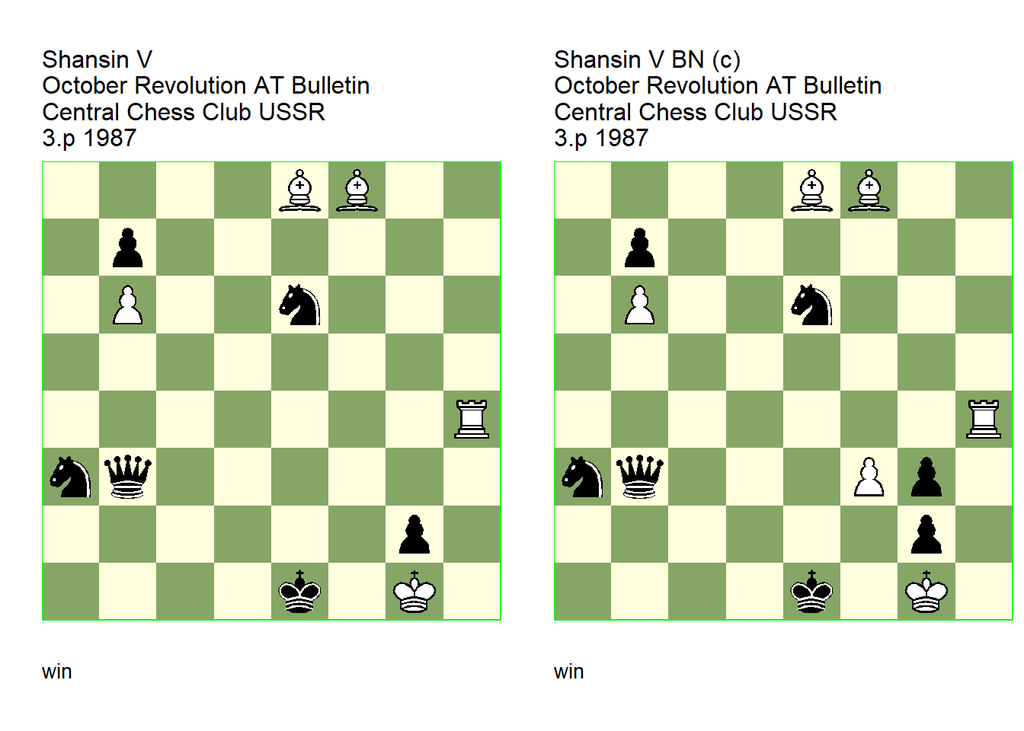

GBR: +3126.12g1e1 U2 FEN: 4BB2/1p6/1P2n3/8/7R/nq6/6p1/4k1K1 w - - 0 1

Bulletin Central Chess Club USSR=33(403) Bulletin Central Chess Club USSR/11 (EG#07105). U2: Garcia=M HHdbV#26242 23-9-2011. Comment: Neuenschwander=B beatochess 23/05/2025. **1. Re4+ Kd2 2. Bh6+ Ng5!** (2… Kc2 3. Ba4 Nc5 4. Bxb3+ Kxb3 5. Re7 Nc4 is unclear ( **BN** ) ) **3. Bxg5+ Kd1 4. Ba4** (4. Rd4+! **cook** MG 4… Kc2 (4… Ke2 5. Bh5+) 5. Ba4 Kc3 6. Bxb3 Kxd4 7. Bf6+) **4… Nc2! 5. Re1+!** (5. Bxb3?) **5… Kxe1 6. Bxb3 Nd4 7. Bd5 Nf3+ 8. Kxg2!** (8. Bxf3?) **8… Nxg5 9. Kg3 Kd2 10. Kf4 Kc3 11. Ke5! Kb4 12. Kd6 Kb5 13. Kc7 Kc5 14. Kxb7! Kxd5 15. Ka8! 1-0**.

GBR: +3126.23g1e1 (c) FEN: 4BB2/1p6/1P2n3/8/7R/nq3Pp1/6p1/4k1K1 w - - 0 1

correction: Neuenschwander=B beatochess 23/05/2025. **1. Re4+ Kd2 2. Bh6+ Ng5! 3. Bxg5+ Kd1 4. Ba4** (4. Rd4+ Ke2 5. Re4+ Kd1) **4… Nc2! 5. Re1+! Kxe1 6. Bxb3 Nd4 7. Bd5 Nxf3+ 8. Kxg2 Nxg5 9. Kxg3 Kd2 10. Kf4 Kc3 11. Ke5 Kb4 12. Kd6 Kb5 13. Kc7 Kc5 14. Kxb7 Kxd5 15. Ka8! 1-0**.

## Miscellaneous

### Katsnelson & Maksimovskikh =0000.24d4b8 (1987). Cook, correction

Date: May 14, 2025

File: Katsnelson1987a.pgn

**4. Kd5!** cooks the study.

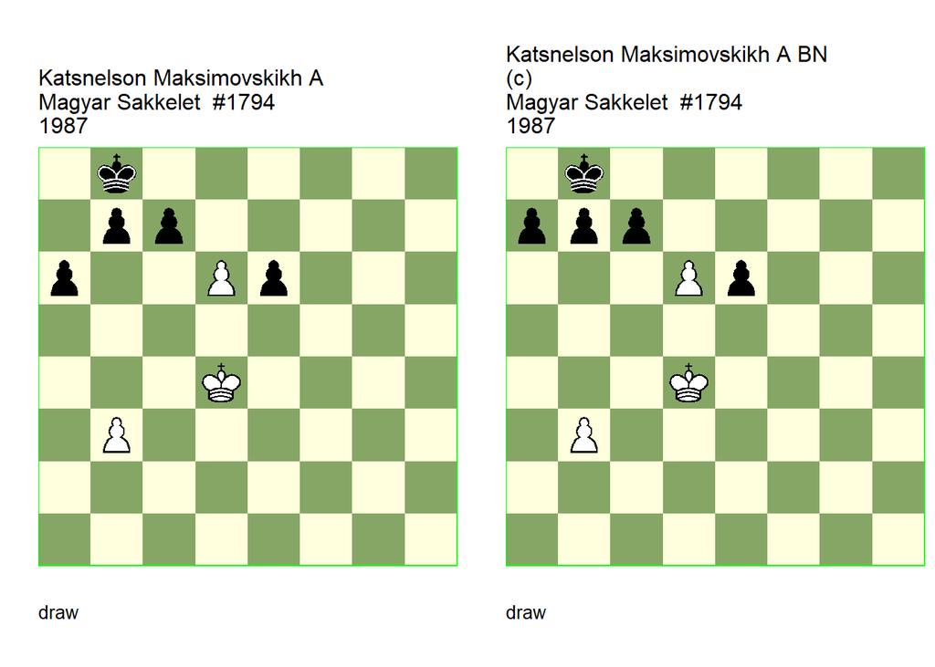

GBR: =0000.24d4b8 U2 FEN: 1k6/1pp5/p2Pp3/8/3K4/1P6/8/8 w - - 0 1

Magyar Sakkelet/11. U2: Neuenschwander=B beatochess 14/05/2025. **1. d7 c5+ 2. Ke5 Kc7 3. Kxe6 Kd8 4. Kd6** (4. Kd5! **cook** **BN** 4… c4 5. Kxc4 Kxd7 6. Kc5 Kc7 7. b4 b6+ 8. Kc4) **4… c4 5. bxc4 a5 6. Kc5 Kxd7 7. Kb6!** (7. Kb5? Kd6 8. Ka4 Kc6 9. Kxa5 Kc5) **7… Kd6 8. Kb5! Ke5 9. Kxa5 1/2-1/2**.

GBR: =0000.24d4b8 (c) FEN: 1k6/ppp5/3Pp3/8/3K4/1P6/8/8 w - - 0 1

correction: Neuenschwander=B beatochess 14/05/2025. **1. d7 c5+ 2. Ke5 Kc7 3. Kxe6 Kd8 4. Kd6** (4. Kd5? Kxd7 5. Kxc5 Ke6) **4… c4 5. bxc4 a5 6. Kc5 Kxd7 7. Kb6** (7. Kb5? Kd6 8. Ka4 Kc6 9. Kxa5 Kc5) **7… Kd6 8. Kb5! Ke5 9. Kxa5 1/2-1/2**.